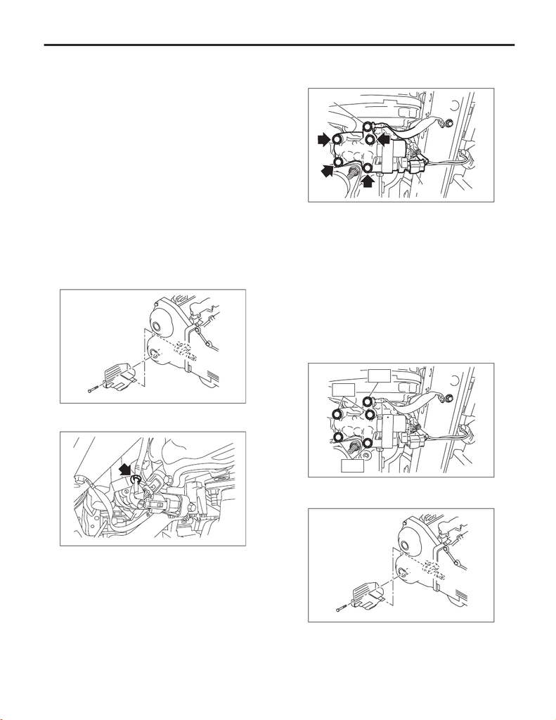

Oil Flow Control Solenoid Valve

FUEL INJECTION (FUEL SYSTEMS)

14.Oil Flow Control Solenoid

Valve

A: REMOVAL

1. INTAKE SIDE

Oil flow control solenoid valve is a unit with front

camshaft cap.

Refer to “Camshaft” for removal procedures. <Ref.

to ME(STI)-62, REMOVAL, Camshaft.>

2. EXHAUST SIDE

1) Disconnect the ground cable from battery.

2) Lift up the vehicle.

3) Remove the under cover. <Ref. to EI-21, RE-

MOVAL, Front Under Cover.>

4) Remove the front exhaust pipe. (right side only.)

<Ref. to EX(STI)-5, REMOVAL, Front Exhaust

Pipe.>

5) Remove the engine harness cover. (right side

only.)

6) Remove the clip holding the engine harness.

(Left side only)

7) Disconnect the ground cable (A). (Left side only)

8) Disconnect the connector (B) from the oil flow

control solenoid valve, and remove the oil flow con-

trol solenoid valve from the cylinder head.

B: INSTALLATION

1. INTAKE SIDE

Refer to “Camshaft” for installation procedure.

<Ref. to ME(STI)-64, INSTALLATION, Camshaft.>

2. EXHAUST SIDE

Install in the reverse order of removal.

NOTE:

Use a new gasket.

Tightening torque:

T1: 7.5 N·m (0.8 kgf-m, 5.5 ft-lb)

T2: 10 N·m (1.0 kgf-m, 7.4 ft-lb)

Tightening torque:

5 N·m (0.5 kgf-m, 3.7 ft-lb)

FU-03616

FU-08481

FU-05832

(A)

(B)

FU-03605

T1

T2

T2

FU-03616

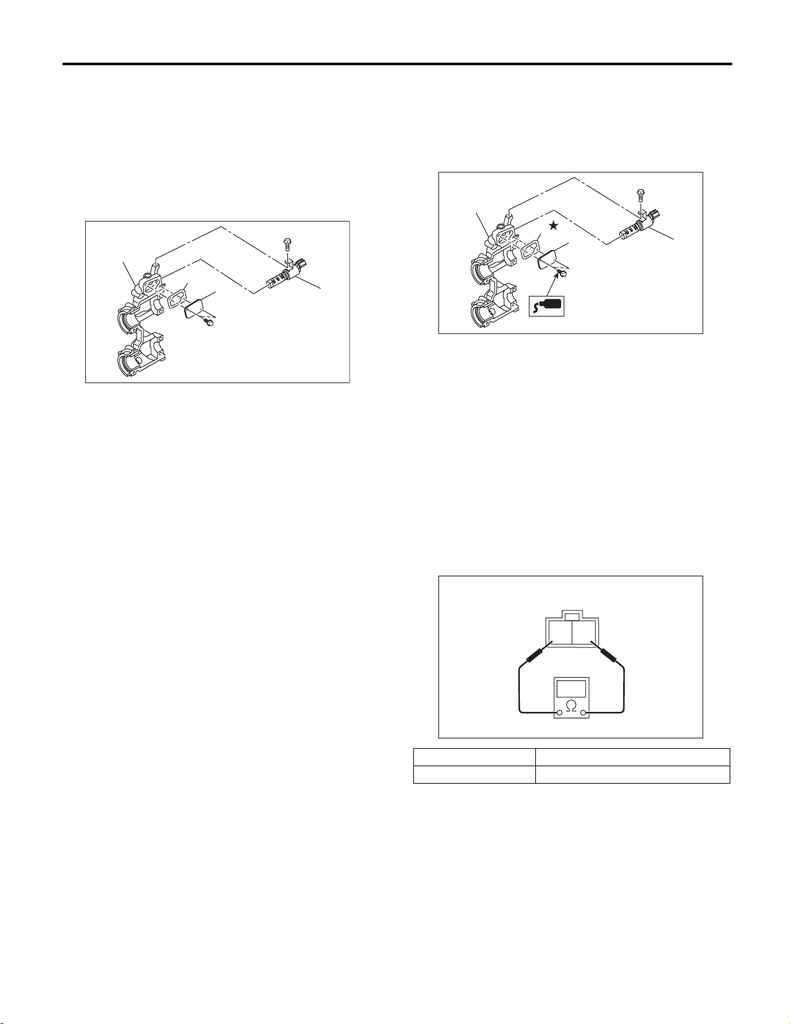

Oil Flow Control Solenoid Valve

FUEL INJECTION (FUEL SYSTEMS)

C: DISASSEMBLY

1. INTAKE SIDE

1) Remove the two mounting bolts securing oil re-

turn cover, and remove the oil return cover and

gasket.

2) Remove the bolt securing oil flow control sole-

noid valve, and remove the oil flow control solenoid

valve.

2. EXHAUST SIDE

The oil flow control solenoid valve on the exhaust

side cannot be disassembled.

D: ASSEMBLY

1. INTAKE SIDE

1) Install the oil flow control solenoid valve.

Tightening torque:

6.4 N·m (0.7 kgf-m, 4.7 ft-lb)

2) Apply liquid gasket to the two bolts securing oil

return cover.

Liquid gasket:

THREE BOND 1324 (Part No. 004403042) or

equivalent

3) Attach the oil return cover and gasket.

Tightening torque:

9 N·m (0.9 kgf-m, 6.6 ft-lb)

NOTE:

Use a new gasket.

2. EXHAUST SIDE

The oil flow control solenoid valve on the exhaust

side cannot be disassembled.

E: INSPECTION

1) Check that the oil flow control solenoid valve has

no deformation, cracks or other damages.

2) Measure the resistance between the oil flow

control solenoid valve terminals.

(A) Oil flow control solenoid valve

(B) Oil return cover

(C) Gasket

(D) Front camshaft cap

FU-05699

(A)

(D)

(C)

(B)

(A) Oil flow control solenoid valve

(B) Oil return cover

(C) Gasket

(D) Front camshaft cap

Terminal No. Standard

1 and 2 7.4±0.5 Ω (when 20°C (68°F))

FU-05700

(A)

(D)

(C)

(B)

2

1

EC-02428